# presentacion-tesis

[figure not shown]

Universidad Nacional de Loja

Facultad de la Energía, las Industrias y los Recursos Naturales No Renovables · Ingeniería en Ciencias de la Computación

## Evaluación del rendimiento de un clúster de bajo costo basado en Raspberry Pi orquestado con Kubernetes

Autor Diego Oswaldo Márquez Paccha

Director Ing. Cristian Ramiro Narváez Guillén, Mg. Sc.

Loja – Ecuador 2026

## Agenda

- Problemática y pregunta de investigación
- Objetivos
- Objetivo 1 — Construcción del prototipo físico
- Objetivo 2 — Evaluación del rendimiento
- Discusión de resultados
- Conclusiones y recomendaciones

## Problemática y Pregunta

Contexto La nube comercial y los servidores tradicionales son una **barrera de costo** para la academia.

? Pregunta de investigación ¿Cuál es el nivel de **latencia** y **throughput** que presenta un clúster orquestado con **Kubernetes** para el despliegue de aplicaciones web contenerizadas, al someterse a una **simulación de carga** en una arquitectura de **bajo costo**?

Limitación Hardware de recursos limitados, sobre todo en **red**: en la Raspberry Pi 3 el Ethernet pasa por el **bus USB**.

Alternativa **Clúster de Raspberry Pi** con Kubernetes ligero (K3s): económico y reproducible.

Vacío Poca evidencia de su **rendimiento bajo carga** y de **qué lo limita**.

## Conceptos clave

**Clúster** — varios equipos que operan como uno solo.

**Kubernetes y K3s** — administra las aplicaciones (contenedores) en varios equipos; K3s es su versión ligera.

**Maestro y trabajadores** — el maestro coordina; los trabajadores ejecutan.

**Latencia y throughput** — cuánto tarda cada respuesta y cuántas peticiones se atienden por segundo.

**Thermal throttling** — a 80–85 °C el procesador reduce su frecuencia para protegerse.

[figure not shown]

Arquitectura de un clúster con Kubernetes: el maestro coordina y los trabajadores ejecutan

## Objetivos

### Objetivo General

Medir el nivel de **latencia** y **throughput** que presenta un clúster orquestado con Kubernetes para el despliegue de aplicaciones web contenerizadas, al someterse a una simulación de carga en una arquitectura de bajo costo.

### Objetivos Específicos

1. **Construir el prototipo físico** del clúster de bajo costo, abarcando desde el diseño de la topología de red hasta la instalación y configuración base del sistema operativo en los nodos, para garantizar una base estable y funcional al momento de la orquestación con Kubernetes.
2. **Orquestar el despliegue de aplicaciones web** en el clúster mediante Kubernetes, sometiendo el sistema a simulaciones de carga para registrar las métricas de latencia y throughput.

## Objetivo 1 — Construcción del prototipo físico

01

## Metodología — Diseño de la carcasa

1 Empatizar Cómputo local, asequible y reproducible

2 Definir El reto: una carcasa a medida

3 Idear Modelado 3D en TinkerCAD

4 Prototipar Impresión 3D en PLA · 8 piezas

5 Evaluar Ajuste frente a los requisitos

**8**piezas impresas en PLA

**17 × 17 × 14**centímetros

**2 + 1**ventiladores y switch integrados

[figure not shown]

Diseño 3D final de la carcasa

## Metodología — Equipos, red y orquestación

Maestro Raspberry Pi 4B · 4 GB

3 trabajadores Raspberry Pi 3 · 1 GB

Switch y router Fast Ethernet · MikroTik

IP estática por nodo

[figure not shown]

Topología de red del clúster

[figure not shown]

**Todos los comandos**  
Escanea el código o visita:  
github.com/eval-cluster/cluster

**Entorno estable**Kernel y firmware con versiones bloqueadas.

**K3s**Primero el maestro; luego se unen los trabajadores.

**Telemetría por nodo**Pantalla OLED con CPU, temperatura y memoria.

## Resultado — Prototipo físico

- Carcasa **impresa en 3D**: 4 nodos, ventiladores y switch en un solo cuerpo
- **Telemetría** en pantalla por nodo
- **Costo: 464 USD**

[figure not shown]

**Diseño 3D del clúster**  
Escanea el código o visita:  
[tinkercad.com/things/cluster-4-raspberrypi](https://www.tinkercad.com/things/l75tymLzWOO-cluster-4-raspberrypi)

[figure not shown]

Clúster ensamblado

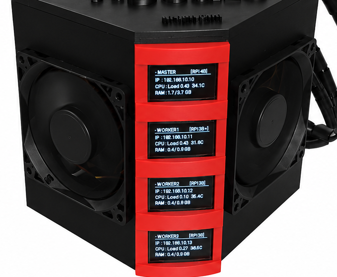

Pantallas con el estado de cada nodo

## Resultado — Clúster operativo

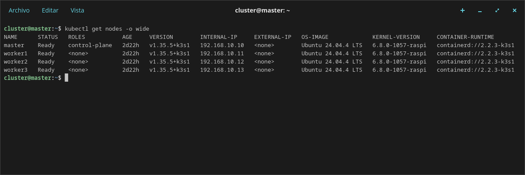

Los cuatro nodos activos (kubectl get nodes -o wide)

**4 nodos en estado Ready** — orquestados con K3s.

**0 fallos de nodo** en las 21 ejecuciones → entorno estable y determinista.

## Objetivo 2 — Evaluación del rendimiento

02

## Metodología — Hipótesis de partida

1 Pruebas preliminares La latencia se dispara bajo la carga más exigente.

2 Hipótesis *Thermal throttling* de los procesadores.

3 Diseño experimental Carcasa con refrigeración activa y comparación **con / sin ventiladores**.

## Metodología — Cómo se midió

- **Aplicación:** NGINX, 3 réplicas
- **Carga (K6):** 50, 200 y 500 usuarios virtuales
- **Escenarios:** con y sin ventiladores · 3 repeticiones
- **Monitoreo:** Prometheus y Grafana

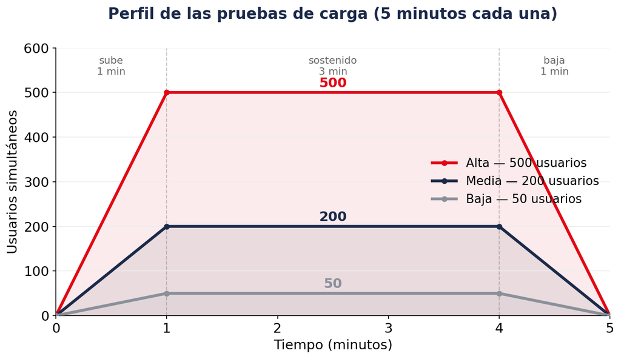

Perfil de las pruebas de carga generadas con Grafana K6

18 ejecuciones de 5 min · ambiente a 21 °C · cada ejecución inicia con el maestro bajo 72 °C (sin ventiladores) o bajo 35 °C (con ventiladores)

## Resultado — Despliegue de la aplicación web

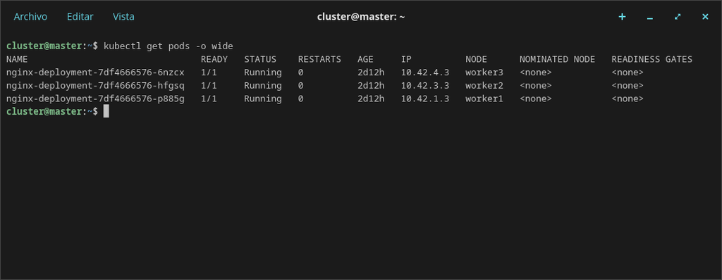

Una réplica de NGINX en cada trabajador (kubectl get pods -o wide)

**NGINX con 3 réplicas** — una por nodo trabajador.

**K3s orquesta** incluso en nodos de solo 1 GB de RAM.

## Resultado — Rendimiento por carga

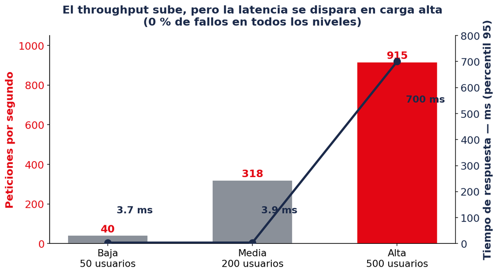

Throughput (barras) y latencia p95 (línea) según la carga

- **Throughput:** 40 → 318 → **915** peticiones/s
- **Latencia p95:** ≈ 4 ms hasta 200 usuarios; **700 ms** con 500

Se satura con 500 usuarios, pero **sin un solo fallo**.

## Resultado — Enfriar casi no mejora

- Maestro: **74 °C → 35 °C**
- Throughput: solo **+1.6 %**

No hubo *thermal throttling*: la temperatura **no limita** el rendimiento web.

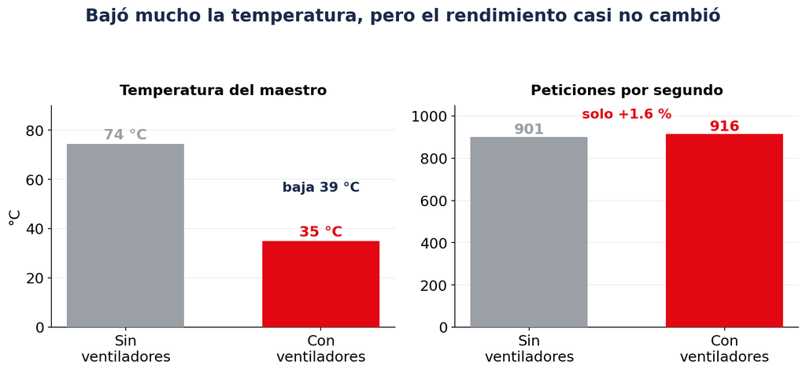

Mucho enfriamiento, casi ninguna mejora

74.33 → 34.93 °C · latencia p95 −0.2 % · umbral de 80–85 °C nunca alcanzado

## Resultado — Qué está pasando por dentro

Tiempo en espera de respuesta del total de cada petición

**99 %**

Uso de CPU nodos trabajadores

**menos del 28 %**

Ocupación del enlace 100 Mbps

**8 %**

Ni la CPU ni el ancho de banda están saturados: el retardo ocurre **antes de que empiece la respuesta**.

K6: `http_req_waiting` 433.26 ms (99.1 %) · `http_req_receiving` 3.82 ms (0.9 %) · 8.31 Mbps

## Resultado — Tráfico distribuido

Throughput +3.4 % apenas mejora

Latencia p95 +24 % y más irregular

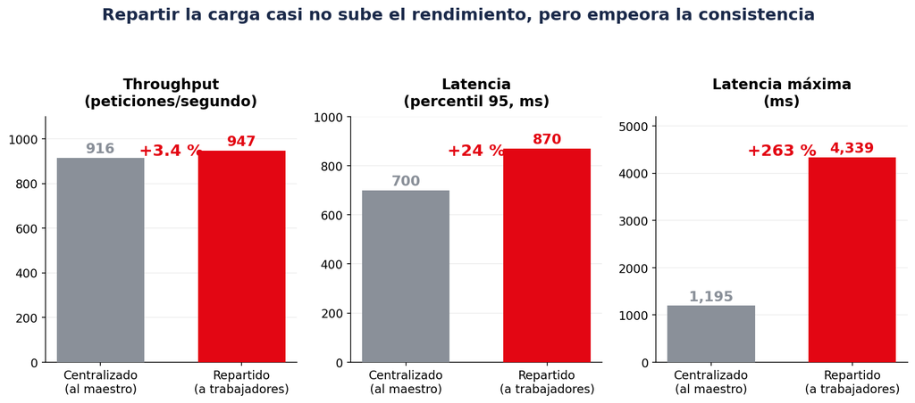

Centralizado frente a distribuido, con carga alta

El límite **no era el maestro**: cada trabajador recibe el tráfico por su propia interfaz, igual de restringida.

## Resultado — El cuello de botella

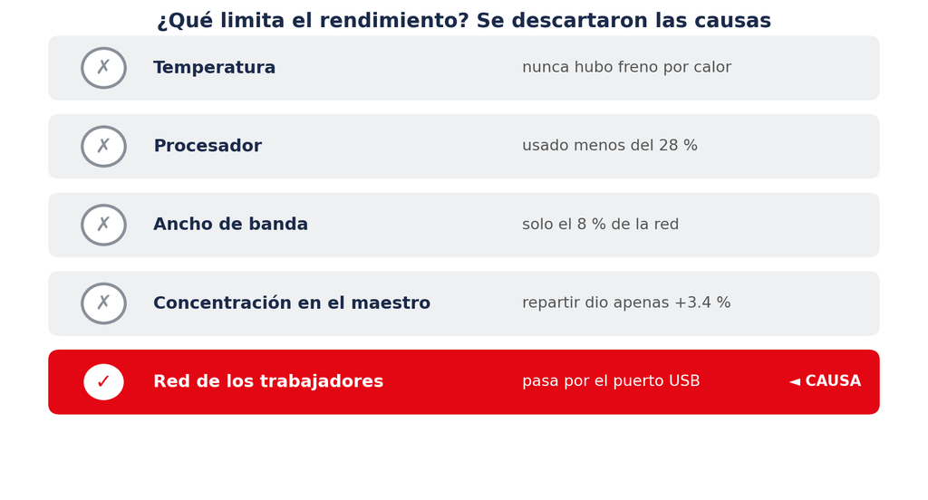

Descarte de causas: el límite es la red de los trabajadores

Factor limitante, **por descarte de causas**: la **red de los nodos trabajadores**. En la Raspberry Pi 3, el Ethernet pasa por el **bus USB**.

## Analogía — La interfaz de red como factor limitante

[figure not shown]

Velocidades nominales de cada puerto (Gupta et al.); en el prototipo, el switch Fast Ethernet fija todos los enlaces en 100 Mbps: la diferencia está en el camino (bus USB compartido frente a controlador dedicado) · atribución por descarte de causas y literatura; el mecanismo exacto queda como trabajo futuro

## Discusión

03

## Discusión — Comparación con otros estudios

Mejora al enfriar Benoit-Cattin et al.

Inferencia de IA · CPU al límite

**+90 %**

Aquí · carga web

**+1.6 %**

Latencia media Sidharta et al. · K3s + NGINX

4 Raspberry Pi 4 · red Gigabit

**3120 ms**

Aquí · Raspberry Pi 3 · 100 Mbps

**437 ms**

Costo y fiabilidad Portillo · Lakshminarayanan 464 USD menos que el servidor comercial más económico (500–1500 USD) 0.00 % fallos en las 21 ejecuciones

Enfriar rinde en cargas **intensivas en CPU**, no en carga web. La **red** también limita a Raspberry Pi 4B y 5 (Gamess y Winston): es una restricción estructural, no un defecto de este prototipo.

## Discusión — Qué significa

En cargas web, invertir primero en **red**, no en refrigeración: la CPU no pasó del 28 %.

La refrigeración **protege el hardware**: 74 → 35 °C. Entre 10 y 15 °C menos pueden duplicar su vida útil.

El sobrecosto de diseño **no se repite**: modelo 3D público, réplica por ≈ 50 USD de material.

## Discusión — Limitaciones

3 repeticiones CV < 0.6 %: tendencias consistentes, sin inferencia estadística formal.

Un solo tipo de carga Web estática: carga de referencia reproducible.

Clúster heterogéneo Refleja la reutilización real de hardware; dificulta aislar cada variable.

Sin grupo de contraste con red dedicada: el bus USB se señala por descarte de causas y literatura.

Pruebas de 5 minutos Alcanzan el régimen estacionario; no miden la degradación prolongada.

## Conclusiones y Recomendaciones

04

## Respuesta a la pregunta de investigación

> ¿Cuál es el nivel de **latencia** y **throughput** que presenta un clúster orquestado con Kubernetes para el despliegue de aplicaciones web contenerizadas, al someterse a una simulación de carga en una arquitectura de bajo costo?

Throughput

≈ 915

peticiones por segundo, bajo carga alta  
(40 y 318 en carga baja y media)

Latencia

≈ 700 ms

**El clúster es viable**: atendió toda la carga **sin un solo fallo**. Su límite está en la **red**, no en el cómputo ni en la temperatura.

## Conclusiones — Cumplimiento de los objetivos

Objetivo general ✓ Cumplido Latencia y throughput **medidos** en 21 ejecuciones consistentes; además se determinó el **factor limitante**.

Objetivo específico 1 ✓ Cumplido Prototipo **estable, funcional y reproducible**: 0 fallos en las 21 ejecuciones.

Objetivo específico 2 ✓ Cumplido Despliegue web con Kubernetes **exitoso**, con métricas registradas bajo carga.

## Recomendaciones técnicas

1 Priorizar la red Trabajadores con Ethernet dedicado (Raspberry Pi 4 o superior) **y** switch Gigabit.

2 Mantener la refrigeración Por la vida útil del hardware, no por el rendimiento web.

3 Almacenamiento de estado sólido En lugar de tarjetas microSD.

## Recomendaciones para trabajos futuros

Replicar en un clúster homogéneo con red dedicada, para verificar de forma directa el cuello de botella.

Ampliar los tipos de carga CPU intensiva, bases de datos, archivos grandes.

Más repeticiones y pruebas más largas

Uso docente del prototipo, por su bajo costo.

## Demostración — El clúster en vivo

[figure not shown]

**1**Escanee el código con sus datos móviles. **2**Pulse el botón verde: la página la sirve este clúster. **3**Observe cuántas personas hay conectadas y el uso de recursos. cluster-tesis.tail846bd3.ts.net

## Gracias por su atención.

Diego Oswaldo Márquez Paccha — Universidad Nacional de Loja

[figure not shown]

**Resultados completos y modelo 3D**  
Escanea el código o visita domp55.github.io/presentacionTesis/evidencia  
Servida desde este clúster: cluster-tesis.tail846bd3.ts.net